# Chicago Crime Data

Taehwan Kim

4/4/2019

# Final Project Milestone 4/5

### Data

I got the data of chicago crime from the City of Chicago’s Open Data Poral that was required by Mayor Rahm Emmanuel. The data is updated everyday and lists crime data from 2001, so I just used one date (4/4/2019) as an end point. The data lists every reported crime since the start date and shows information about it like date; time; type of crime reported; whether an arrest was made; and location.

I plan on running multiple analyses of the data, trying to see the relation between arrest rate with race, a map with crime that shows up by time and date (per year possibly because of how much data there is), seeing how and which type of crime changed over time, arrest rates per crime type.

### Graph

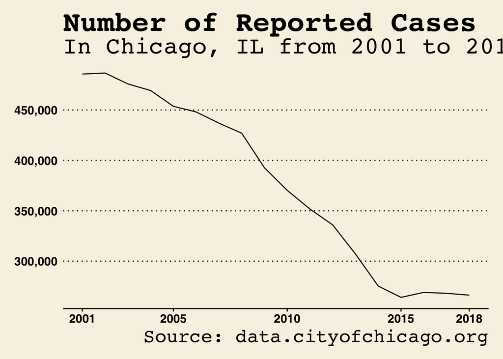

This graph shows reported crime over time and it can be seen that reported crime significantly goes down as time went on since 2001. Perhaps I could next see how arrests are affected?